# Third Week: Exploratory Data Analysis

LaLiga Analysis

امین رخشا ۹۵۱۰۹۳۱۵

2018-02-27 00:00:38

[figure not shown]

# تمرین سری سوم: از لالیگا تا لیگ برتر

> با استفاده از داده های لیگ دسته اول اسپانیا به سوالات زیر پاسخ دهید. از هر دو ابزار ggplot2 و highcharter برای این کار تصویرسازی استفاده نمایید.

## کارهای اولیه

```r
library(engsoccerdata)
library(dplyr)
library(highcharter)
library(ggplot2)
library(ggthemes)
library(tidyr)
library(knitr)
library(kableExtra)
library(captioner)
library(scales)

theme_set(theme_gdocs())

tbls <- captioner(prefix="Table")

data = as.tbl(spain) %>% filter(tier == 1, round == "league") %>% select(-tier)

resultByGD = function(GD) {
  result = rep("W", length(GD))
  result[which(GD < 0)] = rep("L", sum(GD < 0))
  result[which(GD == 0)] = rep("D", sum(GD == 0))
  return(result)
}

homeStat = data %>%
  rename(team = home,
         opp = visitor,
         GF = hgoal,
         GA = vgoal) %>%
  mutate(GD = GF - GA) %>%
  mutate(result = resultByGD(GD))

visitorStat = data %>%
  rename(team = visitor,
         opp = home,
         GF = vgoal,
         GA = hgoal) %>%
  mutate(GD = GF - GA) %>%
  mutate(result = resultByGD(GD))

stat = union(homeStat, visitorStat)
```

۱. تعداد قهرمانی های تیم ها در تاریخ لالیگا را استخراج کرده و نمودار ستونی آنها را رسم کنید.

```r
seasonResults = stat %>% group_by(Season, team) %>%
  summarise(
    W = sum(GD > 0),
    L = sum(GD < 0),
    D = sum(GD == 0),
    GD = sum(GD)
  ) %>%
  mutate(Pts = W * 3 + D) %>%
  arrange(-Season, -Pts, -GD) %>%
  group_by(Season) %>%
  mutate(rank = row_number(-Pts))

championStat = seasonResults %>% group_by(team) %>%
  summarise(championships = sum(rank == 1)) %>%
  filter(championships > 0) %>%
  arrange(desc(championships))
hchart(championStat,
       type = 'bar',
       hcaes(x = team, y = championships),
       name = "championships") %>%
  hc_title(text = "La Liga Champions") %>%
  hc_xAxis(title = list(enabled = FALSE),
           tickInterval = 5) %>%
  hc_yAxis(title = list(text = "Championships"))
```

[interactive chart not shown]

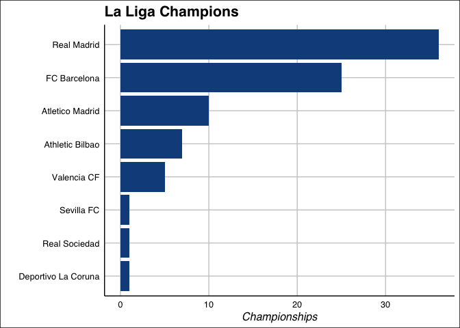

```r
ggplot(championStat, aes(x = reorder(team, championships), y = championships)) +
  geom_bar(stat = "identity", fill = "dodgerblue4") +
  labs(x = "", y = "Championships", title = "La Liga Champions") +
  coord_flip()
```

۲. کسل کننده ترین لیگ و تیم را بیابید. نمودار ده تیم و ده فصل کسل کننده را رسم کنید.

میزان جذابیت یک بازی را تعداد گل های آن در نظر می گیریم. بر همین اساس حذابیت یک تیم یا یک فصل را میانگین تعداد گل ها در بازی هایش تعریف می کنیم.

```r
boringTeams = stat %>%
  group_by(team) %>%
  summarise(goals = sum(GF + GA),
            games = n()) %>%
  mutate(avgGoals = round(goals / games, 2)) %>%
  arrange(avgGoals) %>%
  slice(1:10)
kable(boringTeams[1,], caption = "Most Boring Team")
```

Most Boring Team

| team | goals | games | avgGoals |
| --- | --- | --- | --- |
| Real Burgos | 240 | 114 | 2.11 |

```r
hchart(boringTeams,
       type = 'column',
       hcaes(x = team, y = avgGoals),
       name = "average goals per game")%>%
  hc_title(text = "Most Boring Teams") %>%
  hc_yAxis(title = list(text = "Average Goals Happend in Games")) %>%
  hc_xAxis(title = list(enabled = FALSE))
```

[interactive chart not shown]

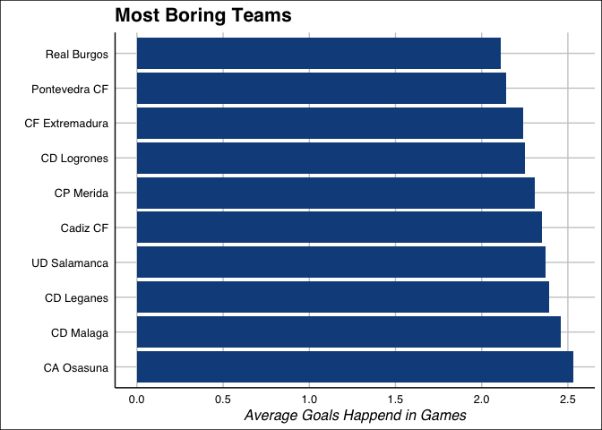

```r
ggplot(boringTeams, aes(x = reorder(team, -avgGoals), y = avgGoals)) +
  geom_bar(stat = "identity", fill = "dodgerblue4") +
  labs(x = "", y = "Average Goals Happend in Games", title = "Most Boring Teams") +
  coord_flip()
```

```r
#Most Boring Seasons
boringSeasons = stat %>%
  group_by(Season) %>%
  summarise(goals = sum(GF),
            games = n() / 2) %>%
  mutate(avgGoals = round(goals / games, 2)) %>%
  arrange(avgGoals) %>%
  slice(1:10)
kable(boringSeasons[1,], caption = "Most Boring Season")
```

Most Boring Season

| Season | goals | games | avgGoals |
| --- | --- | --- | --- |
| 1972 | 656 | 306 | 2.14 |

```r
hchart(boringSeasons,
       type = 'column',
       hcaes(x = as.factor(Season), y = avgGoals),
       name = "average goals per game")%>%
  hc_title(text = "Most Boring Seasons") %>%
  hc_yAxis(title = list(text = "Average Goals Happend in Games")) %>%
  hc_xAxis(title = list(text = "Season"))
```

[interactive chart not shown]

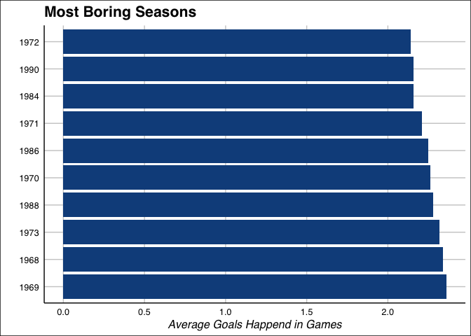

```r
ggplot(boringSeasons, aes(x = reorder(Season, -avgGoals), y = avgGoals)) +
  geom_bar(stat = "identity", fill = "dodgerblue4") +
  labs(x = "", y = "Average Goals Happend in Games", title = "Most Boring Seasons") +
  coord_flip()
```

۳. در چند درصد موارد قهرمان نیم فصل در پایان فصل قهرمان شده است؟

مطابق کد زیر در 52.32558 درصد موارد قهرمان، قهرمان نیم فصل هم بوده است.

```r
stat = stat %>%
  arrange(Date) %>%
  group_by(Season, team, opp) %>%
  mutate(halfSeason = row_number())
halfSeasonResults = stat %>%
  filter(halfSeason == 1) %>%
  group_by(Season, team) %>%
  summarise(
    W = sum(GD > 0),
    L = sum(GD < 0),
    D = sum(GD == 0),
    GD = sum(GD)
  ) %>%
  mutate(Pts = W * 3 + D) %>%
  arrange(-Season, -Pts, -GD) %>%
  group_by(Season) %>%
  mutate(rank = row_number(-Pts))

seasonChampions = full_join(
  seasonResults %>%
    filter(rank == 1) %>%
    select(Season, Champion = team),
  halfSeasonResults %>%
    filter(rank == 1) %>%
    select(Season, halfSeasonChampion = team),
  by = "Season"
)
sum(seasonChampions$Champion == seasonChampions$halfSeasonChampion) / nrow(seasonChampions) * 100
```

```
## [1] 52.32558
```

```r
true = sum(seasonChampions$Champion == seasonChampions$halfSeasonChampion)
false = sum(seasonChampions$Champion != seasonChampions$halfSeasonChampion)
halfChampStat <- data.frame(result = c('True', 'False'), count = c(true, false))
halfChampStat %>%
  hchart(type = "pie", hcaes(x = result, y = count)) %>%
  hc_title(text = 'Half Season Champion = Champion')
```

[interactive chart not shown]

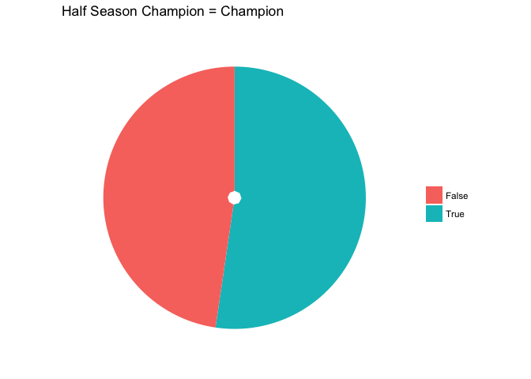

```r
ggplot(halfChampStat, aes(x = "", y = count)) +
  geom_bar(aes(fill = result), stat = 'identity') +
  coord_polar("y", start=0) +
  theme_minimal()+
  theme(
    axis.title.x = element_blank(),
    axis.title.y = element_blank(),
    panel.border = element_blank(),
    panel.grid=element_blank(),
    axis.ticks = element_blank(),
    axis.text.x=element_blank()) +
  labs(x = "", y = "", title = 'Half Season Champion = Champion', fill = "")
```

۴. در بین سال های ۲۰۰۱ تا ۲۰۱۰ گربه سیاه تیم های بزرگ چه تیم هایی بوده است؟

۷ تیمی که بیشترین میانگین امتیاز در بازی را داشته اند را تیم های بزرگ در نظر می گیریم. گربه سیاه یک تیم بزرگ تیمی است که تیم بزرگ در برابر آن بیشترین درصد باخت را دارد و یک تیم بزرگ نیست. در صورتی که تساوی رخ دهد، تیمی که در مجموع تفاضل گل بهتری در برابر تیم بزرگ داشته است گربه سیاه است.

```r
bigTeams = stat %>%
  group_by(team) %>%
  summarise(score = 3 * sum(GD > 0) + sum(GD == 0),
            games = n()) %>%
  mutate(avgScore = score / games) %>%
  arrange(-avgScore) %>%
  slice(1:7) %>%
  .$team

blackCats = stat %>%
  filter(Season >= 2001, Season <= 2010, team %in% bigTeams, !(opp %in% bigTeams)) %>%
  group_by(team, opp) %>%
  summarise(loseRate = sum(GD < 0) / n(), GD = sum(GD)) %>%
  arrange(-loseRate, GD) %>%
  group_by(team) %>%
  summarise(blackCat = first(opp), loseRate = first(loseRate), GD = first(GD))
kable(blackCats, caption = tbls(name="blackCats","Big Teams Black Cats"))
```

Table 1: Big Teams Black Cats

| team | blackCat | loseRate | GD |
| --- | --- | --- | --- |
| Athletic Bilbao | Deportivo La Coruna | 0.5 | -7 |
| Atletico Madrid | CA Osasuna | 0.5 | -3 |
| FC Barcelona | Hercules CF | 0.5 | 1 |
| Real Madrid | UD Las Palmas | 0.5 | 5 |
| Sevilla FC | Hercules CF | 0.5 | -1 |
| Valencia CF | Racing Santander | 0.5 | -1 |
| Villarreal CF | CD Alaves | 0.5 | -1 |

۵. در تاریخ لالیگا کدام تیم رکورددار زودترین قهرمانی است؟ همچنین کدام تیم مقتدرانه ترین قهرمانی را داشته است؟

```r
stat = stat %>%
  mutate(gainedScore = 3 * (GD > 0) + (GD == 0)) %>%
  arrange(Date) %>%
  group_by(Season, team) %>%
  mutate(
    currentScore = cumsum(gainedScore),
    currentGD = cumsum(GD),
    week = row_number(),
    remainingGames = n() - week
  ) %>%
  arrange(-Season, -week, -currentScore, -currentGD) %>%
  group_by(Season, week) %>%
  mutate(currentRank = row_number())


weekResults = stat %>%
  select(Season, Date, week, team, remainingGames, currentScore, currentRank) %>%
  arrange(-Season, -week, currentRank) %>%
  group_by(Season, week) %>%
  mutate(
    startDate = min(Date),
    top3Dist = lag(lag(lag(currentScore))) - currentScore,
    botDist = currentScore - lead(currentScore)
  ) %>%
  select(-Date)

fastestChampionships = weekResults %>%
  filter(currentRank == 1, botDist > 3 * remainingGames) %>%
  group_by(Season) %>%
  top_n(n = 1, -week) %>%
  ungroup() %>%
  arrange(-remainingGames)  %>%
  select(-startDate, -top3Dist, -currentRank) %>%
  rename(score = currentScore, dist = botDist)

kable(fastestChampionships %>% top_n(n = 1, remainingGames),
      caption = tbls(name="fastestChampionships","Fastest Championships"))
```

Table 2: Fastest Championships

| Season | week | team | remainingGames | score | dist |
| --- | --- | --- | --- | --- | --- |
| 1990 | 33 | FC Barcelona | 5 | 78 | 17 |
| 1974 | 29 | Real Madrid | 5 | 63 | 16 |
| 1973 | 29 | FC Barcelona | 5 | 64 | 16 |
| 1962 | 25 | Real Madrid | 5 | 62 | 17 |
| 1960 | 25 | Real Madrid | 5 | 68 | 21 |

```r
fastest10Championships = fastestChampionships %>% slice(1:10)

hchart(fastest10Championships,
       type = 'bar',
       hcaes(x = paste(team, '(', Season, ')'), color = team, y = remainingGames),
       name = "remaining games") %>%
  hc_title(text = "Fastest Championships") %>%
  hc_xAxis(title = list(enabled = FALSE),
           tickInterval = 1) %>%
  hc_yAxis(title = list(text = "Remaining Games"))
```

[interactive chart not shown]

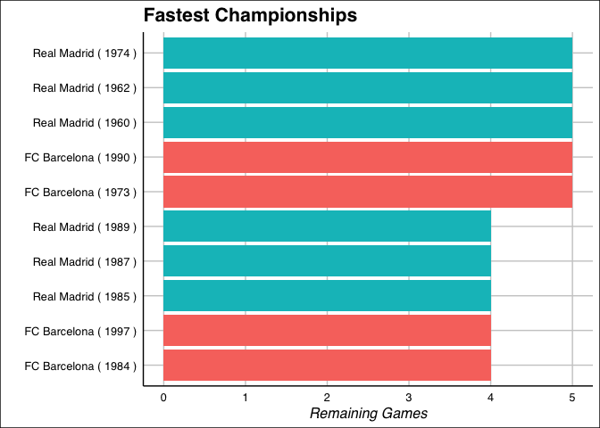

```r
ggplot(fastest10Championships, aes(x = reorder(paste(team, '(', Season, ')'), remainingGames), y = remainingGames)) +
  geom_bar(aes(fill = team), stat = "identity") +
  labs(x = "", y = "Remaining Games", title = "Fastest Championships") +
  coord_flip() +
  guides(fill = F)
```

میزان اقتدار یک قهرمانی را نسبت امتیاز قهرمان به امتیاز تیم دوم در نظر می گیریم.

```r
bestChampionships = weekResults %>%
  ungroup() %>%
  filter(remainingGames == 0, currentRank == 1) %>%
  mutate(distRatio = currentScore / (currentScore - botDist)) %>%
  arrange(-distRatio) %>%
  select(-startDate, -top3Dist, -currentRank, -remainingGames) %>%
  rename(score = currentScore, dist = botDist)

kable(bestChampionships %>% top_n(n = 5, wt = distRatio),
      caption = tbls(name="bestChampionships","Best Championships"))
```

Table 3: Best Championships

| Season | week | team | score | dist | distRatio |
| --- | --- | --- | --- | --- | --- |
| 1962 | 30 | Real Madrid | 72 | 21 | 1.411765 |
| 1960 | 30 | Real Madrid | 76 | 19 | 1.333333 |
| 1974 | 34 | Real Madrid | 70 | 17 | 1.320755 |
| 1985 | 34 | Real Madrid | 82 | 19 | 1.301587 |
| 1984 | 34 | FC Barcelona | 74 | 15 | 1.254237 |

```r
best10Championships = bestChampionships %>% slice(1:10)

hchart(best10Championships,
       type = 'bar',
       hcaes(x = paste(team, '(', Season, ')'), color = team, y = distRatio),
       name = "Distance Ratio") %>%
  hc_title(text = "Fastest Championships") %>%
  hc_xAxis(title = list(enabled = FALSE)) %>%
  hc_yAxis(title = list(text = "Distance Ratio"))
```

[interactive chart not shown]

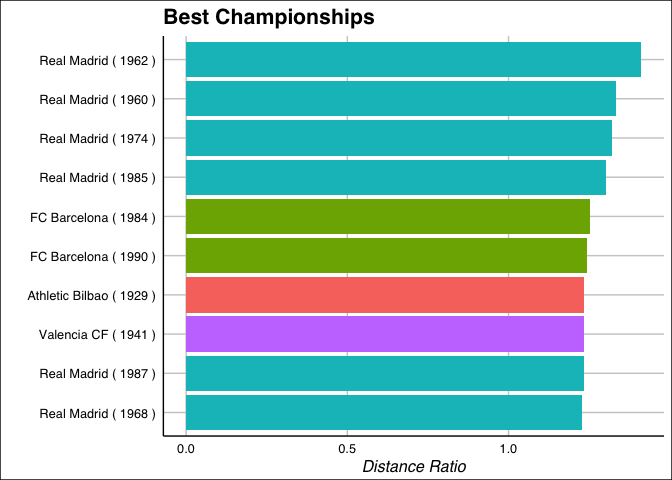

```r
ggplot(best10Championships, aes(x = reorder(paste(team, '(', Season, ')'), distRatio), y = distRatio)) +
  geom_bar(aes(fill = team), stat = "identity") +
  labs(x = "", y = "Distance Ratio", title = "Best Championships") +
  coord_flip() +
  guides(fill = F)
```

۶. طولانی ترین نوار پیروزی مساوی و شکست مال چه تیم هایی است؟

```r
streak = function(results) {
  isChanged = results != lag(results)
  isChanged[1] = FALSE
  streakNo = cumsum(isChanged)
  streak = data_frame(streakNo) %>%
    group_by(streakNo) %>%
    mutate(streak = row_number()) %>%
    .$streak
  return(streak)
}

stat = stat %>%
  arrange(Season, week) %>%
  group_by(team) %>%
  mutate(streak = streak(result))
```

طولانی ترین نوار برد به طور مشترک برای بارسلونا و رئال مادرید و به طول ۱۶ بوده است:

```r
winStreak = stat %>%
  filter(result == "W") %>%
  ungroup() %>%
  top_n(n = 1, wt = streak) %>%
  select(team, length = streak, EndDate = Date, EndOpp = opp, EndFTResult = FT)
kable(winStreak, caption = tbls(name="winStreak","Longest Win Streak"))
```

Table 4: Longest Win Streak

| team | length | EndDate | EndOpp | EndFTResult |
| --- | --- | --- | --- | --- |
| FC Barcelona | 16 | 2011-02-05 | Atletico Madrid | 3-0 |
| Real Madrid | 16 | 2016-09-18 | Espanyol Barcelona | 0-2 |

طولانی ترین نوار باخت برای UD Las Palmas و به طول ۱۱ بوده است:

```r
loseStreak = stat %>%
  filter(result == "L") %>%
  ungroup() %>%
  top_n(n = 1, wt = streak) %>%
  select(team, length = streak, EndDate = Date, EndOpp = opp, EndFTResult = FT)
kable(loseStreak, caption = tbls(name="loseStreak","Longest Lose Streak"))
```

Table 5: Longest Lose Streak

| team | length | EndDate | EndOpp | EndFTResult |
| --- | --- | --- | --- | --- |
| UD Las Palmas | 11 | 1960-02-21 | Real Zaragoza | 6-2 |

طولانی ترین نوار مساوی برای Burgos CF و به طول ۹ بوده است:

```r
drawStreak = stat %>%
  filter(result == "D") %>%
  ungroup() %>%
  top_n(n = 1, wt = streak) %>%
  select(team, length = streak, EndDate = Date, EndOpp = opp, EndFTResult = FT)
kable(drawStreak, caption = tbls(name="drawStreak","Longest Draw Streak"))
```

Table 6: Longest Draw Streak

| team | length | EndDate | EndOpp | EndFTResult |
| --- | --- | --- | --- | --- |
| Burgos CF | 9 | 1978-10-22 | Real Madrid | 2-2 |

۷. زودترین سقوط مال کدام تیم بوده است؟

فرض می کنیم هر فصل سه تیم سقوط می کنند. سقوط هایی که هنگام قطعی شدن آن ها بازی های بیشتری از فصل مانده است را پیدا می کنیم.

```r
fastestFalls = weekResults %>%
  group_by(Season) %>%
  filter(currentRank == max(currentRank),
         top3Dist > 3 * remainingGames) %>%
  top_n(n = 1, -week) %>%
  ungroup() %>%
  arrange(-remainingGames)  %>%
  select(-startDate, -botDist, -currentRank) %>%
  rename(score = currentScore, dist = top3Dist)

kable(fastestFalls %>% top_n(n = 1, remainingGames),
      caption = tbls(name="fastestFalls","Fastest Falls"))
```

Table 7: Fastest Falls

| Season | week | team | remainingGames | score | dist |
| --- | --- | --- | --- | --- | --- |
| 1997 | 31 | Sporting Gijon | 7 | 9 | 25 |

```r
fastest10Falls = fastestFalls %>% slice(1:10)
hchart(fastest10Falls,
       type = 'bar',
       hcaes(x = paste(team, '(', Season, ')'), color = team, y = remainingGames),
       name = "remaining games") %>%
  hc_title(text = "Fastest Falls") %>%
  hc_xAxis(title = list(enabled = FALSE),
           tickInterval = 1) %>%
  hc_yAxis(title = list(text = "Remaining Games"))
```

[interactive chart not shown]

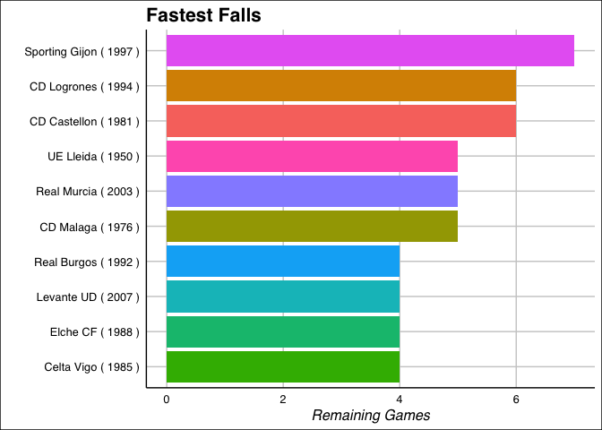

[figure not shown]

```r
ggplot(fastest10Falls, aes(x = reorder(paste(team, '(', Season, ')'), remainingGames), y = remainingGames)) +
  geom_bar(aes(fill = team), stat = "identity") +
  labs(x = "", y = "Remaining Games", title = "Fastest Falls") +
  coord_flip() +
  guides(fill = F)
```

مانند شکل بالا تصویری از روند تغییر رتبه تیم ها در طول فصل ۱۹۹۸ رسم نمایید.

```r
ranking = seasonResults %>%
  filter(Season == 1998) %>%
  .$team

season1998 <- weekResults %>%
  filter(Season == 1998)
season1998 %>%
  hchart(type = "line", hcaes(x = startDate, y = currentRank, group = team)) %>%
  hc_xAxis(title = list(enabled = FALSE),
           tickInterval = 1,
           type = 'datetime',
           labels = list(rotation = -45,
                         format = '{value:%b %e}')) %>%
  hc_yAxis_multiples(
    list(
      title = list(text = "Position"),
      reversed = TRUE,
      min = 1,
      max = 20,
      tickInterval = 1
    )
  )
```

[interactive chart not shown]

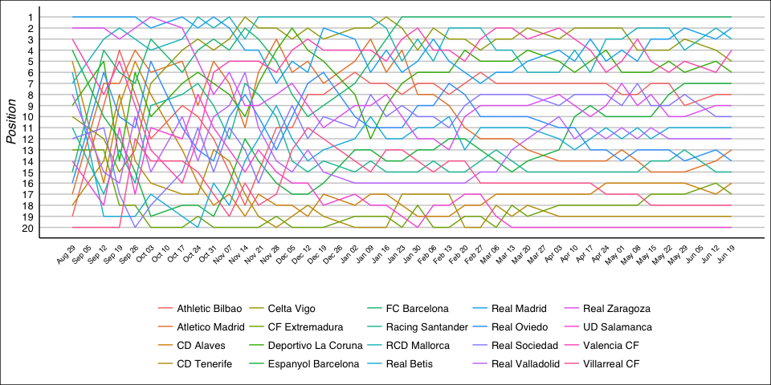

[figure not shown]

```r
dateBreaks = seq.Date(from = min(season1998$startDate),
                  to = max(season1998$startDate),
                  by = 'week')

season1998 %>%
  ggplot(aes(
    x = startDate,
    y = currentRank,
    group = team,
    color = team
  )) +
  scale_x_date(breaks = dateBreaks, labels = date_format("%b %d")) +
  scale_y_reverse(breaks = 1:20) +
  geom_line() +
  # guides(color = F) +
  labs(x = "", y = "Position") +
  theme(panel.grid.major.x=element_blank(),
        panel.grid.minor.x=element_blank(),
        axis.text.x = element_text(angle=45, size = 7, hjust = 1,vjust=1),
        legend.position = 'bottom',
        legend.direction = "horizontal",
        legend.title = element_blank())
```

۹. جدولی مشابه بالا برای فصل ۲۰۱۲ از کل نتایج طراحی کنید.

با استفاده از پکیج tidyr می توانیم به data frame ی به شکل خواسته شده برسیم. که در زیر می بینید:

```r
#Q9
resultTable = homeStat %>%
  filter(Season == 2012) %>%
  select(team, opp, FT) %>%
  spread(opp, FT)

kable(resultTable, "html") %>%
  kable_styling('striped', full_width = TRUE) %>%
  scroll_box(width = "800px", height = "600px")
```

| team | Athletic Bilbao | Atletico Madrid | CA Osasuna | Celta Vigo | Deportivo La Coruna | Espanyol Barcelona | FC Barcelona | Getafe CF | Granada CF | Levante UD | Malaga CF | Rayo Vallecano | RCD Mallorca | Real Betis | Real Madrid | Real Sociedad | Real Valladolid | Real Zaragoza | Sevilla FC | Valencia CF |
| --- | --- | --- | --- | --- | --- | --- | --- | --- | --- | --- | --- | --- | --- | --- | --- | --- | --- | --- | --- | --- |
| Athletic Bilbao | NA | 3-0 | 1-0 | 1-0 | 1-1 | 0-4 | 2-2 | 1-2 | 1-0 | 0-1 | 0-0 | 1-2 | 2-1 | 3-5 | 0-3 | 1-3 | 2-0 | 0-2 | 2-1 | 1-0 |
| Atletico Madrid | 4-0 | NA | 3-1 | 1-0 | 6-0 | 1-0 | 1-2 | 2-0 | 5-0 | 2-0 | 2-1 | 4-3 | 0-0 | 1-0 | 1-2 | 0-1 | 2-1 | 2-0 | 4-0 | 1-1 |
| CA Osasuna | 0-1 | 0-2 | NA | 1-0 | 2-1 | 0-2 | 1-2 | 1-0 | 1-2 | 4-0 | 0-0 | 1-0 | 1-1 | 0-0 | 0-0 | 0-0 | 0-1 | 1-0 | 2-1 | 0-1 |
| Celta Vigo | 1-1 | 1-3 | 2-0 | NA | 1-1 | 1-0 | 2-2 | 2-1 | 2-1 | 1-1 | 0-1 | 0-2 | 1-1 | 0-1 | 1-2 | 1-1 | 3-1 | 2-1 | 2-0 | 0-1 |
| Deportivo La Coruna | 1-1 | 0-0 | 2-0 | 3-1 | NA | 2-0 | 4-5 | 1-1 | 0-3 | 0-2 | 1-0 | 0-0 | 1-0 | 2-3 | 1-2 | 0-1 | 0-0 | 3-2 | 0-2 | 2-3 |
| Espanyol Barcelona | 3-3 | 0-1 | 0-3 | 1-0 | 2-0 | NA | 0-2 | 0-2 | 0-1 | 3-2 | 0-0 | 3-2 | 3-2 | 1-0 | 1-1 | 2-2 | 0-0 | 1-2 | 2-2 | 3-3 |
| FC Barcelona | 5-1 | 4-1 | 5-1 | 3-1 | 2-0 | 4-0 | NA | 6-1 | 2-0 | 1-0 | 4-1 | 3-1 | 5-0 | 4-2 | 2-2 | 5-1 | 2-1 | 3-1 | 2-1 | 1-0 |
| Getafe CF | 1-0 | 0-0 | 1-1 | 3-1 | 3-1 | 0-2 | 1-4 | NA | 2-2 | 0-1 | 1-0 | 1-2 | 1-0 | 2-4 | 2-1 | 2-1 | 2-1 | 2-0 | 1-1 | 0-1 |
| Granada CF | 1-2 | 0-1 | 3-0 | 2-1 | 1-1 | 0-0 | 1-2 | 2-0 | NA | 1-1 | 1-0 | 2-0 | 1-2 | 1-5 | 1-0 | 0-0 | 1-1 | 1-2 | 1-1 | 1-2 |
| Levante UD | 3-1 | 1-1 | 0-2 | 0-1 | 0-4 | 3-2 | 0-4 | 0-0 | 3-1 | NA | 1-2 | 2-3 | 4-0 | 1-1 | 1-2 | 2-1 | 2-1 | 0-0 | 1-0 | 1-0 |
| Malaga CF | 1-0 | 0-0 | 1-0 | 1-1 | 3-1 | 0-2 | 1-3 | 2-1 | 4-0 | 3-1 | NA | 1-2 | 1-1 | 4-0 | 3-2 | 1-2 | 2-1 | 1-1 | 0-0 | 4-0 |
| Rayo Vallecano | 2-2 | 2-1 | 2-2 | 3-2 | 2-1 | 2-0 | 0-5 | 3-1 | 1-0 | 3-0 | 1-3 | NA | 2-0 | 3-0 | 0-2 | 0-2 | 1-2 | 0-2 | 0-0 | 0-4 |
| RCD Mallorca | 0-1 | 1-1 | 1-1 | 1-0 | 2-3 | 2-1 | 2-4 | 1-3 | 1-2 | 1-1 | 2-3 | 1-1 | NA | 1-0 | 0-5 | 1-0 | 4-2 | 1-1 | 2-1 | 2-0 |
| Real Betis | 1-1 | 2-4 | 2-1 | 1-0 | 1-1 | 1-0 | 1-2 | 0-0 | 1-2 | 2-0 | 3-0 | 1-2 | 1-2 | NA | 1-0 | 2-0 | 0-0 | 4-0 | 3-3 | 1-0 |
| Real Madrid | 5-1 | 2-0 | 4-2 | 2-0 | 5-1 | 2-2 | 2-1 | 4-0 | 3-0 | 5-1 | 6-2 | 2-0 | 5-2 | 3-1 | NA | 4-3 | 4-3 | 4-0 | 4-1 | 1-1 |
| Real Sociedad | 2-0 | 0-1 | 0-0 | 2-1 | 1-1 | 0-1 | 3-2 | 1-1 | 2-2 | 1-1 | 4-2 | 4-0 | 3-0 | 3-3 | 3-3 | NA | 4-1 | 2-0 | 2-1 | 4-2 |
| Real Valladolid | 2-2 | 0-3 | 1-3 | 0-2 | 1-0 | 1-1 | 1-3 | 2-1 | 1-0 | 2-0 | 1-1 | 6-1 | 3-1 | 0-1 | 2-3 | 2-2 | NA | 2-0 | 1-1 | 1-1 |
| Real Zaragoza | 1-2 | 1-3 | 3-1 | 0-1 | 5-3 | 0-0 | 0-3 | 0-1 | 0-0 | 0-1 | 0-1 | 3-0 | 3-2 | 1-2 | 1-1 | 1-2 | 0-1 | NA | 2-1 | 2-2 |
| Sevilla FC | 2-1 | 0-1 | 1-0 | 4-1 | 3-1 | 3-0 | 2-3 | 2-1 | 3-0 | 0-0 | 0-2 | 2-1 | 3-2 | 5-1 | 1-0 | 1-2 | 1-2 | 4-0 | NA | 4-3 |
| Valencia CF | 3-2 | 2-0 | 4-0 | 2-1 | 3-3 | 2-1 | 1-1 | 4-2 | 1-0 | 2-2 | 5-1 | 0-1 | 2-0 | 3-0 | 0-5 | 2-5 | 2-1 | 2-0 | 2-0 | NA |

اما برای ساخت تصویری مانند آنچه خواسته شده از ggplot استفاده می کنیم:

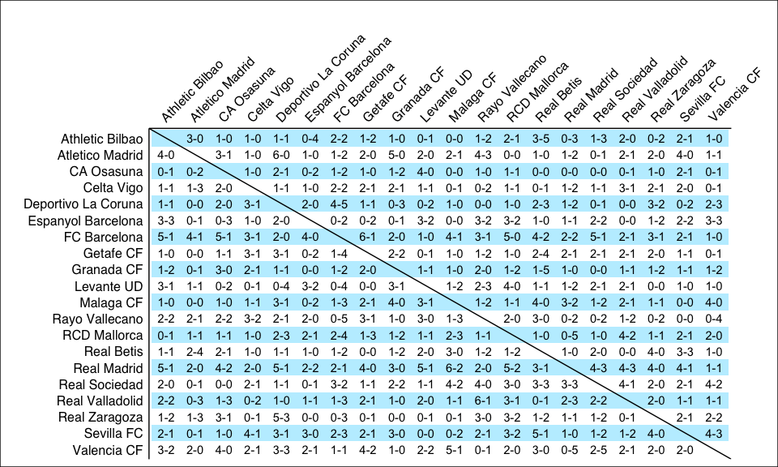

```r
teams = visitorStat %>%
  filter(Season == 2012) %>%
  select(opp) %>%
  unique() %>%
  .$opp

season2012 = bind_rows(
    visitorStat %>%
    filter(Season == 2012),
    data.frame(team = teams, opp = teams, FT = rep("", length(teams)))
  ) %>%
  arrange(opp)

season2012$team = as.factor(season2012$team)
season2012$opp = as.factor(season2012$opp)
ggplot(season2012, aes(team, opp)) +
  geom_tile(aes(fill = as.numeric(opp) %% 2)) +
  geom_text(aes(label = FT)) +
  geom_abline(slope = -1, intercept = 21) +
  scale_fill_gradient2(low = "white",
                       high = "lightblue1",
                       midpoint = 0.5) +
  theme(panel.grid.major.x=element_blank(),
        panel.grid.minor.x=element_blank(),
        panel.grid.major.y=element_blank(),
        panel.grid.minor.y=element_blank(),
        panel.background=element_rect(fill="white"),
        axis.text.x = element_text(angle=45, hjust = 0,vjust=0,size = 12),
        plot.title = element_text(size=20),
        axis.text.y = element_text(size = 12)) +
  theme(legend.title=element_text(size=14)) +
  scale_x_discrete(name="", position = 'top') +
  scale_y_discrete(name="", limits = rev(levels(season2012$opp))) +
  guides(fill = FALSE) +
  theme(plot.margin = unit(c(1, 3, 0.5, 0.5), "lines"))
```

۱۰. سه آماره به همراه نمودار فردوسی پسند استخراج کنید.

در دوره های ۵ ساله، برای هر دوره، مجموع تفاضل گل بارسلونا در ال کلاسیکو ها را استخراج می کنیم و بهترین خط را از آن می گذارنیم. می بینیم که در طی زمان وضعیت بارسلونا در برابر رئال مادرید بهتر شده است!

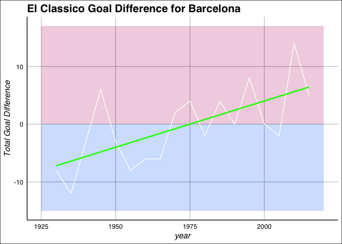

```r
elClassico = stat %>%
  filter(team == "FC Barcelona", opp == "Real Madrid") %>%
  mutate(period = round(Season / 5) * 5) %>%
  group_by(period) %>%
  summarise(GD = sum(GD), result = resultByGD(GD))

ggplot(elClassico, aes(x = period, y = GD)) +
  geom_rect(aes(
    xmin = min(period) - 5,
    xmax = max(period) + 5,
    ymax = max(GD) + 3
  ), ymin = 0,
  alpha = 0.01, fill = "#a50044") +
  geom_rect(aes(
    xmin = min(period) - 5,
    xmax = max(period) + 5,
    ymin = min(GD) - 3
  ), ymax = 0,
  alpha = 0.01, fill = "dodgerblue") +
  geom_line(color = "White") +
  geom_smooth(method = "lm", se = FALSE, color = "green") +
  scale_color_continuous(low = "yellow", high = "#a50044") +
  guides(color = F) +
  labs(x = 'year', y = 'Total Goal Difference', title = "El Classico Goal Difference for Barcelona" )
```

```r
m = lm(elClassico$GD~elClassico$period)
hchart(elClassico,
       type = "line",
       hcaes(x = period, y = GD),
       name = "Goal", color = "white", zIndex = 10) %>%
  hc_add_series(
    type = "area",
    data.frame(period = c(1920, 2020), GD = c(20, 20)),
    hcaes(x = period, y = GD),
    color = "white",
    fillColor = "rgba(165, 0, 68, 0.2)",
    enableMouseTracking = FALSE
  ) %>%
  hc_add_series(
    type = "area",
    data.frame(period = c(1920, 2020), GD = c(-20, -20)),
    hcaes(x = period, y = GD),
    color = "white",
    fillColor = "rgba(30, 144, 255, 0.2)",
    enableMouseTracking = FALSE
  ) %>%
  hc_add_series(
    type = "line",
    data.frame(period = c(1920, 2020), GD = c(-8.75, 7.28)),
    hcaes(x = period, y = GD),
    color = "green",
    enableMouseTracking = FALSE
  ) %>%
  hc_xAxis(title = list(text = "year")) %>%
  hc_yAxis(title = list(text = "Total Goal Difference")) %>%
  hc_title(text = "El Classico Goal Difference for Barcelona")
```

[interactive chart not shown]

از داده ی HT نتیجه ی نیمه ی اول را استخراج می کنیم. برای هر تیم نسبت بازی هایی که در نیمه اول برده اند و را در نهایت باخته اند را به کل بازی هایشان استخراج می کنیم. تیم هایی که بیشترین نسبت را دارند را در نمودار زیر می بینید. جالب است که یک تیم در یک سوم مواقع نیمه ی اول را برده ولی در نهایت باخته است.

```r
halfTime = strsplit(stat$HT, "-")
halfTime = t(as.data.frame(halfTime))
stat$hGF = as.integer(halfTime[,1])
stat$hGA = as.integer(halfTime[,2])

stat = stat %>%
  mutate(hGD = hGF - hGA)

secondHalfLosers = stat %>%
  group_by(team) %>%
  summarise(count = sum(!is.na(HT)), changes = sum((hGF > hGA) & (GF < GA))) %>%
  mutate(perc = changes / count) %>%
  arrange(-perc) %>%
  slice(1:10)

hchart(secondHalfLosers, type = 'bar', hcaes(x = team, y = perc))%>%
  hc_xAxis(title = list(enabled = F)) %>%
  hc_yAxis(title = list(text = "Game Drop Ratio")) %>%
  hc_title(text = "Teams with highest second half loss rate")
```

[interactive chart not shown]

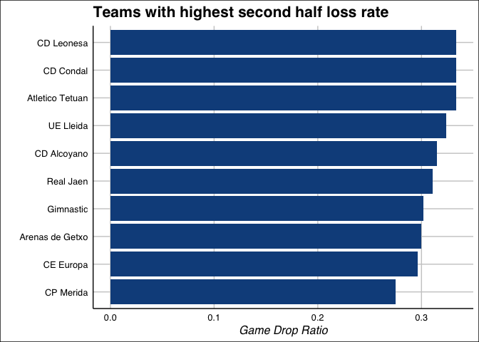

```r
ggplot(secondHalfLosers, aes(x = reorder(team, perc), y = perc)) +
  geom_bar(stat = 'identity', fill = 'dodgerblue4') +
  coord_flip() +
  labs(x = "", y = "Game Drop Ratio", title = "Teams with highest second half loss rate")
```

یکی از دلایل خاطرانگیز بودن یک فصل معلوم نبودن قهرمان تا آخرین بازی ها است. برای هر فصل تعداد تیم هایی که شانس قهرمانی تا قبل از دو بازی آخر را دارند را می شماریم. در۲ فصل ۶ تیم تا آن موقع شانس قهرمانی داشته اند! فصل های با بیشترین تعداد کاندیداهای قهرمانی به شرح زیر هستند:

```r
possibleChampions = weekResults %>%
  filter(remainingGames == 2) %>%
  group_by(Season) %>%
  filter(currentScore >= max(currentScore) - 6) %>%
  summarise(possibleChampions = n()) %>%
  top_n(n = 5, wt = possibleChampions) %>%
  arrange(-possibleChampions)

hchart(possibleChampions, type = 'bar', hcaes(x = as.factor(Season), y = possibleChampions))%>%
  hc_xAxis(title = list(enabled = F)) %>%
  hc_yAxis(title = list(text = "Number of Possible Champions")) %>%
  hc_title(text = "Seasons with Highest Possible Champions")
```

[interactive chart not shown]

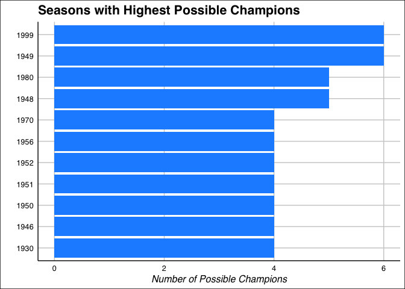

```r
ggplot(possibleChampions, aes(x = reorder(Season, possibleChampions), y = possibleChampions)) +
  geom_bar(stat = 'identity', fill = 'dodgerblue') +
  coord_flip() +
  labs(x = "", y = "Number of Possible Champions", title = "Seasons with Highest Possible Champions")
```